# Fetal Health

Finn de Lange

2025-05-24

**Data import**

```r
data <- read_csv("fetal_health.csv")
```

**Basic summary statistics**

```r
data %>%
  summary()
```

```
##  baseline value  accelerations      fetal_movement     uterine_contractions
##  Min.   :106.0   Min.   :0.000000   Min.   :0.000000   Min.   :0.000000
##  1st Qu.:126.0   1st Qu.:0.000000   1st Qu.:0.000000   1st Qu.:0.002000
##  Median :133.0   Median :0.002000   Median :0.000000   Median :0.004000
##  Mean   :133.3   Mean   :0.003178   Mean   :0.009481   Mean   :0.004366
##  3rd Qu.:140.0   3rd Qu.:0.006000   3rd Qu.:0.003000   3rd Qu.:0.007000
##  Max.   :160.0   Max.   :0.019000   Max.   :0.481000   Max.   :0.015000
##  light_decelerations severe_decelerations prolongued_decelerations
##  Min.   :0.000000    Min.   :0.000e+00    Min.   :0.0000000
##  1st Qu.:0.000000    1st Qu.:0.000e+00    1st Qu.:0.0000000
##  Median :0.000000    Median :0.000e+00    Median :0.0000000
##  Mean   :0.001889    Mean   :3.293e-06    Mean   :0.0001585
##  3rd Qu.:0.003000    3rd Qu.:0.000e+00    3rd Qu.:0.0000000
##  Max.   :0.015000    Max.   :1.000e-03    Max.   :0.0050000
##  abnormal_short_term_variability mean_value_of_short_term_variability
##  Min.   :12.00                   Min.   :0.200
##  1st Qu.:32.00                   1st Qu.:0.700
##  Median :49.00                   Median :1.200
##  Mean   :46.99                   Mean   :1.333
##  3rd Qu.:61.00                   3rd Qu.:1.700
##  Max.   :87.00                   Max.   :7.000
##  percentage_of_time_with_abnormal_long_term_variability
##  Min.   : 0.000
##  1st Qu.: 0.000
##  Median : 0.000
##  Mean   : 9.847
##  3rd Qu.:11.000
##  Max.   :91.000
##  mean_value_of_long_term_variability histogram_width  histogram_min
##  Min.   : 0.000                      Min.   :  3.00   Min.   : 50.00
##  1st Qu.: 4.600                      1st Qu.: 37.00   1st Qu.: 67.00
##  Median : 7.400                      Median : 67.50   Median : 93.00
##  Mean   : 8.188                      Mean   : 70.45   Mean   : 93.58
##  3rd Qu.:10.800                      3rd Qu.:100.00   3rd Qu.:120.00
##  Max.   :50.700                      Max.   :180.00   Max.   :159.00
##  histogram_max histogram_number_of_peaks histogram_number_of_zeroes
##  Min.   :122   Min.   : 0.000            Min.   : 0.0000
##  1st Qu.:152   1st Qu.: 2.000            1st Qu.: 0.0000
##  Median :162   Median : 3.000            Median : 0.0000
##  Mean   :164   Mean   : 4.068            Mean   : 0.3236
##  3rd Qu.:174   3rd Qu.: 6.000            3rd Qu.: 0.0000
##  Max.   :238   Max.   :18.000            Max.   :10.0000
##  histogram_mode  histogram_mean  histogram_median histogram_variance
##  Min.   : 60.0   Min.   : 73.0   Min.   : 77.0    Min.   :  0.00
##  1st Qu.:129.0   1st Qu.:125.0   1st Qu.:129.0    1st Qu.:  2.00
##  Median :139.0   Median :136.0   Median :139.0    Median :  7.00
##  Mean   :137.5   Mean   :134.6   Mean   :138.1    Mean   : 18.81
##  3rd Qu.:148.0   3rd Qu.:145.0   3rd Qu.:148.0    3rd Qu.: 24.00
##  Max.   :187.0   Max.   :182.0   Max.   :186.0    Max.   :269.00
##  histogram_tendency  fetal_health
##  Min.   :-1.0000    Min.   :1.000
##  1st Qu.: 0.0000    1st Qu.:1.000
##  Median : 0.0000    Median :1.000
##  Mean   : 0.3203    Mean   :1.304
##  3rd Qu.: 1.0000    3rd Qu.:1.000
##  Max.   : 1.0000    Max.   :3.000
```

**Investigating correlations**

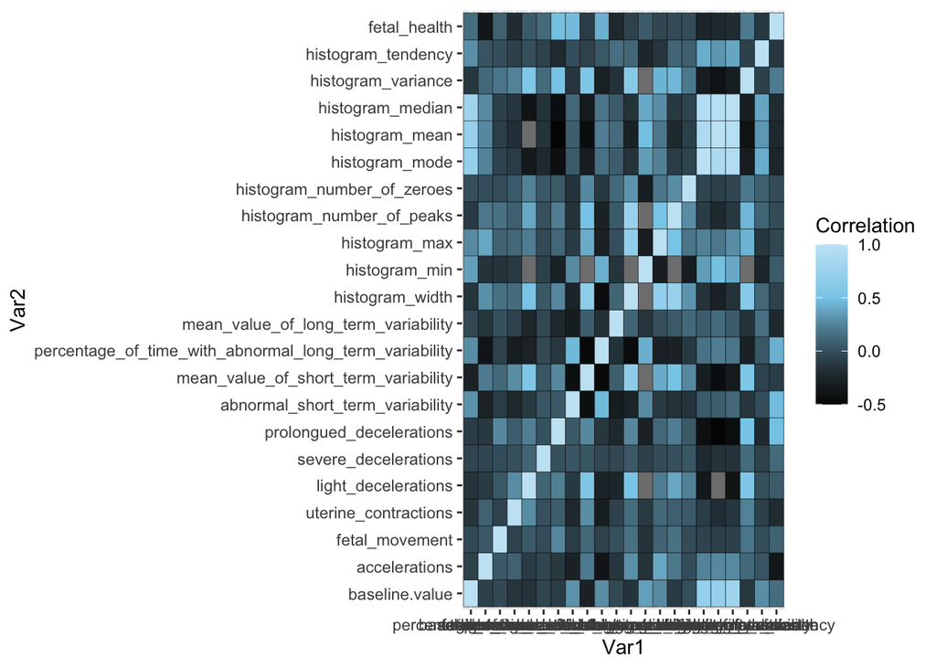

```r
library(reshape2)
library(RColorBrewer)

df_numeric <- as.data.frame(lapply(data, as.numeric))

# Compute correlation matrix
cor_matrix <- cor(df_numeric, use = "pairwise.complete.obs")

# Melt the correlation matrix to long format
cor_melted <- melt(cor_matrix)

# Create heatmap
ggplot(cor_melted, aes(Var1, Var2, fill = value)) +
  geom_tile(color = "black") +
  scale_fill_gradient2(
    low = "black", mid = "skyblue", high = "white",
    midpoint = 0.5, limit = c(-0.5, 1),
    name = "Correlation"
  )
```

There do not appear to be any particularly stand out values that correlate, aside from summary statistics (mean, median and mode of the histogram correlate highly).

Given that the fetal health column is recorded and can tell us if the infant was classified as normal, suspect or pathological, we should be able to create model that can classify into two groups - normal or of concern.

We can first create a new column by collapsing the suspect and pathological groups into a single group, and re-code the system to use 0 for normal and 1 for of concern.

```r
data <- data %>%
  mutate(
    recoded = ifelse(fetal_health == 1, 0, 1)
  ) %>%
  dplyr::select(-fetal_health)
```

**Rudimentary model fitting**

It clear that there will be many variables that suffer from multicolinearity in this dataset. In particular, the summary values of the measures are going to correlate very highly with each other as well as the data they are based on. For this reason, we will aim to reduce the number of dimensions in our dataset, and then perform logistic regression on the reduce dataset.

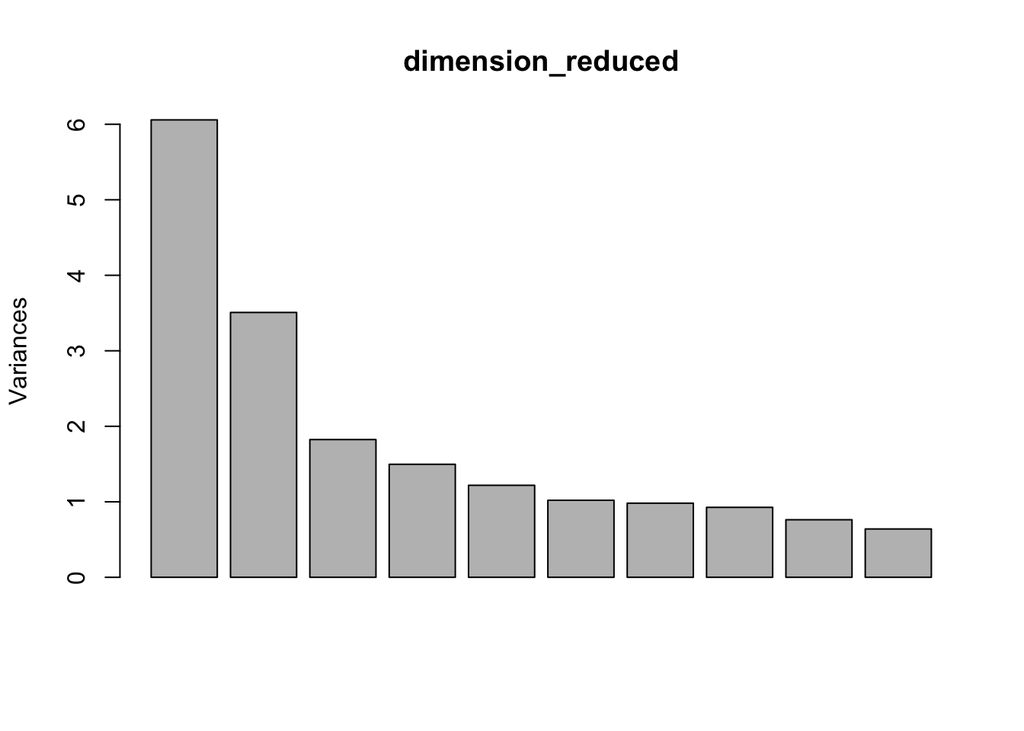

```r
dimension_reduced <- prcomp(data[,1:21], scale = TRUE, center = TRUE)

screeplot(dimension_reduced)
```

```r
sum(dimension_reduced$sdev[1:5]^2)/sum(dimension_reduced$sdev^2)
```

```
## [1] 0.671692
```

```r
round(dimension_reduced$sdev^2 / sum(dimension_reduced$sdev^2), 2)
```

```
##  [1] 0.29 0.17 0.09 0.07 0.06 0.05 0.05 0.04 0.04 0.03 0.03 0.02 0.02 0.02 0.01
## [16] 0.01 0.01 0.01 0.00 0.00 0.00
```

Based on the screeplot and proportion of variance explained, using four of five principal components seems to be a viable option. Given this, we can now begin trying to fit a logistic model.

Let us now consider if we can find any meaningful separation using the principal components.

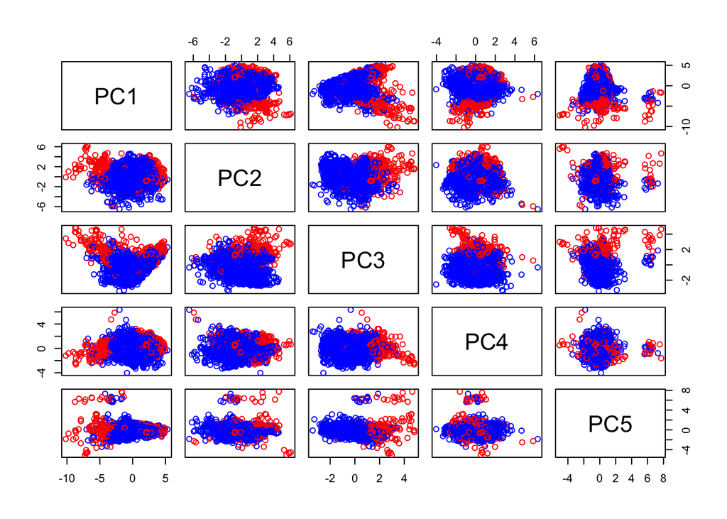

```r
colours <- ifelse(data$recoded == 1, 'red', 'blue')
pairs(dimension_reduced$x[,1:5], col=colours)
```

Based on the plot, we can see that there is significant overlap in many of the principal component pairings, However, there do appear to be a few pairings when there is better separtion than others, such as all of the PC3 groupings. Additionally, all of the PC5 groupings show a smaller cluster that appears to be a mix of normal and of concern infants. This may be worth further investigation at another time, but unfortunately does not aim in solving our problem.

In our next step we will attempt to fit the logistic model, which will involve dredging over all the possible combinations. I have chosen to use AICc as my dredging criteria. We will first consider if any of our derived variables require transformation.

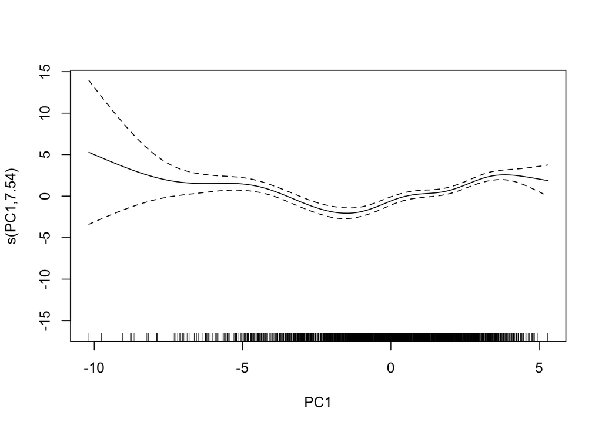

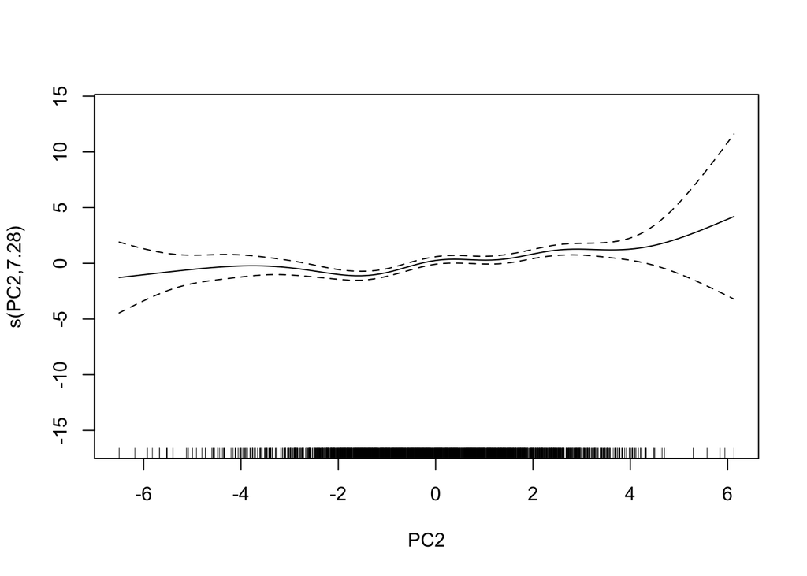

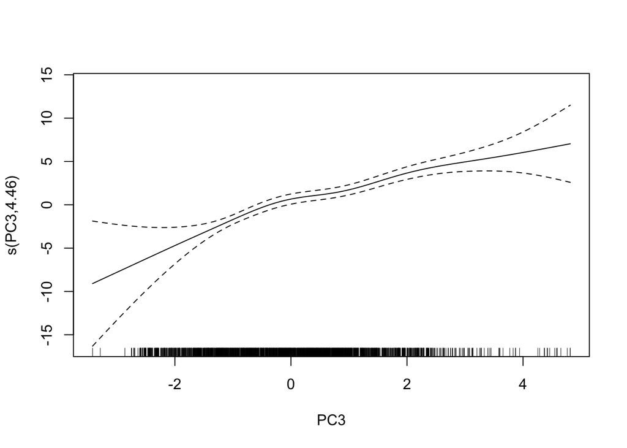

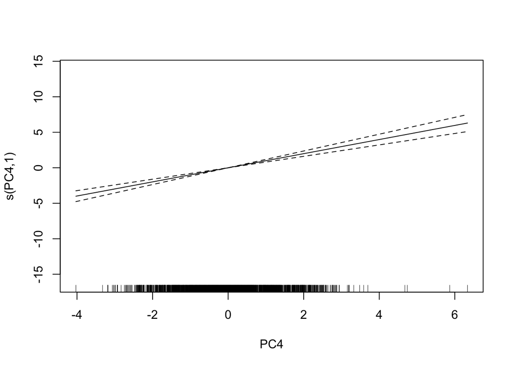

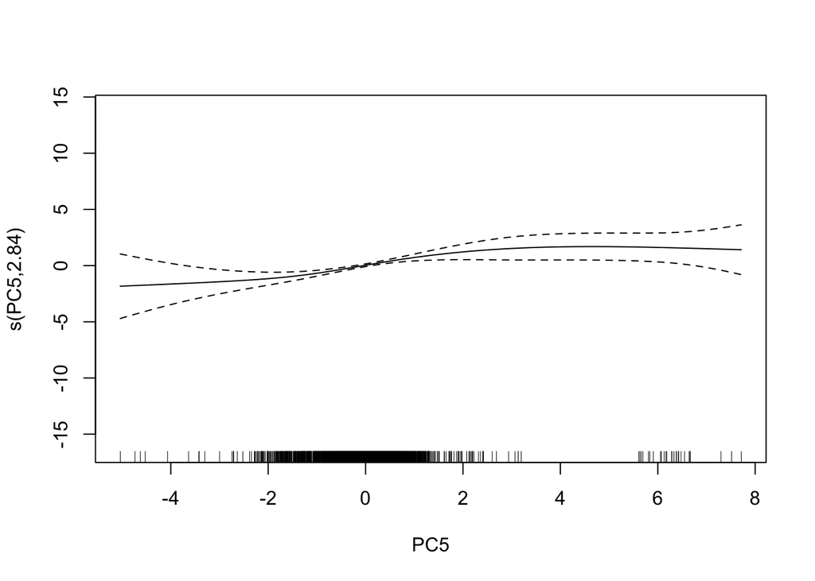

```r
library(mgcv)

derived_data <- as.data.frame(dimension_reduced$x[,1:5])
derived_data$code <- data$recoded

gam.fit <- gam(code ~ s(PC1) + s(PC2) + s(PC3) + s(PC4) + s(PC5), family = "binomial", data = derived_data)

plot(gam.fit)
```

```r
library(MuMIn)

anova(glm(code ~  PC1 * PC2 * PC3 * PC4 * PC5, data = derived_data, family = binomial), test='Chisq')
```

```
## Analysis of Deviance Table
##
## Model: binomial, link: logit
##
## Response: code
##
## Terms added sequentially (first to last)
##
##
##                     Df Deviance Resid. Df Resid. Dev  Pr(>Chi)
## NULL                                 2125    2248.69
## PC1                  1    36.84      2124    2211.85 1.284e-09 ***
## PC2                  1   127.26      2123    2084.59 < 2.2e-16 ***
## PC3                  1   940.01      2122    1144.57 < 2.2e-16 ***
## PC4                  1    83.86      2121    1060.71 < 2.2e-16 ***
## PC5                  1    36.95      2120    1023.77 1.214e-09 ***
## PC1:PC2              1    52.47      2119     971.29 4.365e-13 ***
## PC1:PC3              1    24.86      2118     946.43 6.160e-07 ***
## PC2:PC3              1    13.69      2117     932.74 0.0002152 ***
## PC1:PC4              1     8.15      2116     924.59 0.0043026 **
## PC2:PC4              1     0.86      2115     923.73 0.3543528
## PC3:PC4              1     0.46      2114     923.27 0.4999181
## PC1:PC5              1     7.01      2113     916.26 0.0080988 **
## PC2:PC5              1    14.17      2112     902.10 0.0001672 ***
## PC3:PC5              1     3.11      2111     898.99 0.0779665 .
## PC4:PC5              1     5.33      2110     893.66 0.0209644 *
## PC1:PC2:PC3          1     1.61      2109     892.05 0.2046779
## PC1:PC2:PC4          1     1.59      2108     890.46 0.2068701
## PC1:PC3:PC4          1     1.91      2107     888.54 0.1664591
## PC2:PC3:PC4          1     7.57      2106     880.98 0.0059439 **
## PC1:PC2:PC5          1    13.47      2105     867.50 0.0002422 ***
## PC1:PC3:PC5          1     8.62      2104     858.89 0.0033313 **
## PC2:PC3:PC5          1    19.76      2103     839.12 8.763e-06 ***
## PC1:PC4:PC5          1     5.14      2102     833.98 0.0233177 *
## PC2:PC4:PC5          1     2.95      2101     831.03 0.0857014 .
## PC3:PC4:PC5          1     9.87      2100     821.16 0.0016824 **
## PC1:PC2:PC3:PC4      1     6.43      2099     814.73 0.0112045 *
## PC1:PC2:PC3:PC5      1     3.08      2098     811.64 0.0791515 .
## PC1:PC2:PC4:PC5      1     1.38      2097     810.26 0.2395219
## PC1:PC3:PC4:PC5      1     0.49      2096     809.77 0.4825395
## PC2:PC3:PC4:PC5      1     0.09      2095     809.67 0.7593811
## PC1:PC2:PC3:PC4:PC5  1     2.61      2094     807.07 0.1065096
## ---
## Signif. codes:  0 '***' 0.001 '**' 0.01 '*' 0.05 '.' 0.1 ' ' 1
```

```r
full_model <- glm(code ~ PC1 * PC2 + PC1 * PC3 + PC2 * PC3 + PC1 * PC4 + PC1 * PC5 + PC2 * PC5 + PC4 * PC5, data = derived_data, family = binomial)

options(na.action = "na.fail")

dredged_model <- dredge(full_model)

chosen_model <- get.models(dredged_model, 2)[[1]]

summary(chosen_model)
```

```
##
## Call:
## glm(formula = code ~ PC1 + PC2 + PC3 + PC4 + PC5 + PC1:PC2 +
##     PC1:PC3 + PC1:PC4 + PC1:PC5 + PC2:PC3 + PC2:PC5 + 1, family = binomial,
##     data = derived_data)
##
## Coefficients:
##             Estimate Std. Error z value Pr(>|z|)
## (Intercept) -3.17047    0.19293 -16.433  < 2e-16 ***
## PC1          0.67182    0.08958   7.499 6.41e-14 ***
## PC2          0.35880    0.07367   4.870 1.11e-06 ***
## PC3          2.16145    0.13011  16.613  < 2e-16 ***
## PC4          1.00190    0.10895   9.196  < 2e-16 ***
## PC5          0.89417    0.11302   7.911 2.55e-15 ***
## PC1:PC2     -0.16490    0.02475  -6.663 2.68e-11 ***
## PC1:PC3     -0.24797    0.05639  -4.398 1.09e-05 ***
## PC1:PC4     -0.10730    0.03866  -2.776 0.005505 **
## PC1:PC5      0.07436    0.03359   2.214 0.026851 *
## PC2:PC3      0.30506    0.06472   4.714 2.43e-06 ***
## PC2:PC5      0.22810    0.05916   3.856 0.000115 ***
## ---
## Signif. codes:  0 '***' 0.001 '**' 0.01 '*' 0.05 '.' 0.1 ' ' 1
##
## (Dispersion parameter for binomial family taken to be 1)
##
##     Null deviance: 2248.69  on 2125  degrees of freedom
## Residual deviance:  902.26  on 2114  degrees of freedom
## AIC: 926.26
##
## Number of Fisher Scoring iterations: 8
```

I ended up choosing the second model provided by dredge, as it had a comparable AICc to the first model, but the first model also included a non-significant interaction term while the second model does not.

```r
deviance <- deviance(chosen_model)
df <- df.residual(chosen_model)

# p-value for goodness-of-fit test
1 - pchisq(deviance, df)
```

```
## [1] 1
```

Since we are using principal components, this goodness-of-fit test does not tell us much.

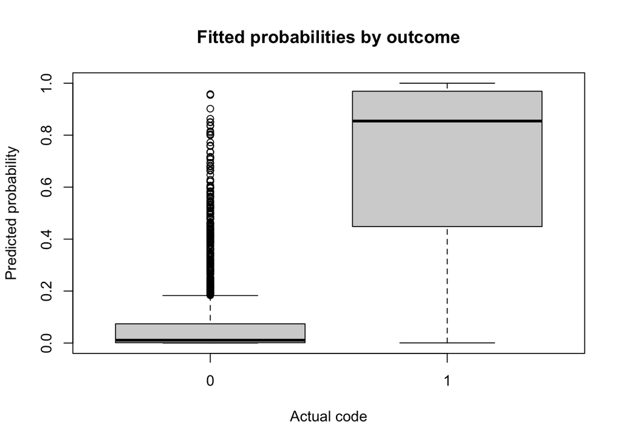

```r
boxplot(fitted(chosen_model) ~ derived_data$code,
        main = "Fitted probabilities by outcome",
        xlab = "Actual code", ylab = "Predicted probability")
```

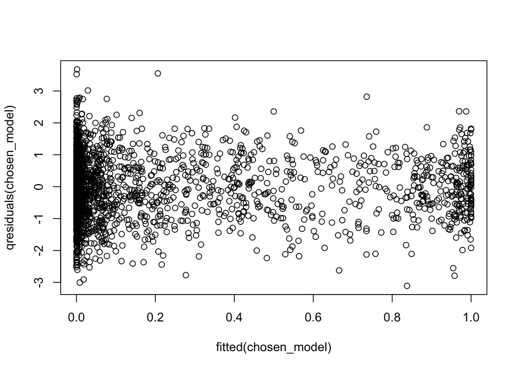

```r
library(statmod)
plot(fitted(chosen_model), qresiduals(chosen_model))
```

Lastly, let us consider our cross-validation to determine how well our model can predict the health of the infants.

```r
library(crossval)

predfun.lm <- function(train.x, train.y, test.x, test.y) {
  glm.fit <- glm(train.y ~ ., data = train.x, family = binomial)
  ynew <- predict(glm.fit, test.x, type = 'response')
  mean((ynew - test.y))^2
}

y.fit1 <- "code"
cv.out = crossval(predfun.lm, X = derived_data[,c('PC1', 'PC2', 'PC3', 'PC4', 'PC5')], Y = derived_data[, y.fit1], K = 10, B = 1, verbose = FALSE)
MSPE_1 <- cv.out$stat
MSPE_1se <- cv.out$stat.se

MSPE_1
```

```
## [1] 0.0004449929
```

```r
MSPE_1se
```

```
## [1] 0.0002290559
```